# Replication: A Novel Hybrid Convolutional Neural Network for Accurate Organ Segmentation in 3D Head and Neck CT Images

Authors:  
Lucas Veeger - 4459628  
Emma Botten - 5616042  
Storm Holman - 4645715  
Thomas Zuiker - 4493133

For the treatment planning of head and neck cancers, the segmentation of organs-at-risk in CT images playes an important role. Doing this manually can be time-consuming and error-prone. In order to have a quicker process with robust outcomes, methods for automated segmentation have been proposed.

## 1 OrganNet2.5D

Head and neck cancers are primarily treated with radiation therapy. For this accurate organ, segmentation is needed to prevent complications during the radiation treatment. Computed tomography (CT) is used because of its high efficiency and spatial resolution. However, identifying organs at risk (OARs) is a very time-consuming process. Which can take several hours for one patient. Therefore, automated methods are of urgent need.

### Deep learning problem / model

The problem of organ segmentation from CT images is a classification problem. Where all the voxels in a CT image need to be classified as one of the OARs or not being an OAR. On the left, a 2D slice of a CT image can be seen. On the right, the labeling for two of the OARs. The deep learning model will have to learn where these labels are in the CT image bases on spatial information.

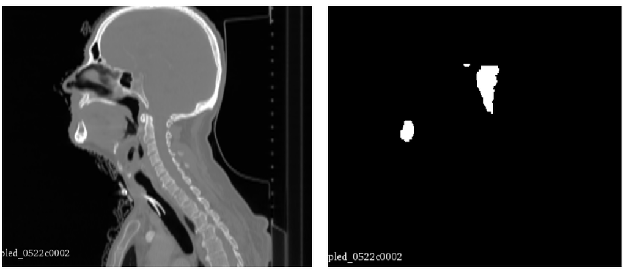

### 1.1 Loss functions

There can often be a problem with data imbalance with medical images. The imbalance problem is both due to the varying sizes of the organs and background, and the imbalance between easy and hard example. The easy and hard examples refer to how easily they can be classified.[1] To prevent the model from biasing large objects, the loss function used is a combination of focal loss and Dice loss.

The first part of the loss function is focal loss, which is given by

$$ L_{\text {focal }}=-\frac{1}{N} \sum_{n=1}^{N} \sum_{c=1}^{C} \alpha_{c}\left(1-p_{n}^{c}\right)^{\gamma} y_{n}^{c} \log p_{n}^{c} $$

Where $p\in [0,1]$ is the network prediction, $y \in {0,1}$ is the manual label and the C refers to the different classes. The loss is averaged over all N pixels. The parameter $\alpha_c$ is the fixed class weights, and $(1-p_n^c)^{\gamma}$ is the dynamic loss weight.

The focal loss will make the model focus more on the predictions with high uncertainty by adjusting the parameters. By increasing $\gamma$ the total weight will decrease, and be less than the fixed $\alpha_c$. This leads to a down-weighting of the easy prediction.

The second part of the total loss, is Dice Loss.

The Dice coefficient (DSC) is calculated as

$$ DSC = \frac{1}{C}\sum_{c=1}^{C} \sum_{n=1}^N \frac{2\cdot p_n^c\cdot y_n^c}{p_n^c + y_n^c} $$

This leads to the following loss function

$$ L_{avgdice} = 1 - DSC $$

The DSC is a measure of the overlap of the prediction and ground truth, i.e. twice the intersection divided by the overlap for each of the 9 organs and the background. The Dice Loss will thus help prevent the model from biasing the large objects in the image. It is worth to mention that according to Zhang [5] the dice loss has some disadvantages that have impact on the training and final performance of the model. The dice loss can't capture the distance between two shapes if they are in the vicinity or very far from each other. Also, it is insensitive to the precise contour of segmented regions because the regions only have a small impact on the overall volume.

The final and combined loss function for the model is $$ L = L_{focal} + \lambda \cdot L_{avgdice} $$

This loss function includes both the Dice loss which deals with the imbalance between the foreground and background, and the focal loss with forces the model to learn the improve on the poorly classified voxels.

```python
class DiceLoss(nn.Module):
    def __init__(self, channels=10):
        super().__init__()
        self.c = channels

    def forward(self, inputs, targets):
        intersection = torch.mul(inputs, targets).sum([2, 3, 4])
        dice = (2. * intersection) / (inputs.sum([2, 3, 4]) + targets.sum([2, 3, 4]))
        dice = dice.sum() / (self.c * inputs.shape[0])

        return 1 - dice


class FocalLoss(nn.Module):
    def __init__(self, gamma, alpha, shape=(2, 10, 256, 256, 48)):
        super().__init__()
        self.DEVICE = torch.device("cuda:0" if torch.cuda.is_available() else "cpu")
        self.gamma = gamma
        self.alpha = alpha.to(self.DEVICE)
        self.n = shape[2] * shape[3] * shape[4]

    def forward(self, inputs, targets):

        focal_loss = self.alpha * torch.pow((1. - inputs), self.gamma) * (targets * torch.log(inputs + 1e-7))
        focal_loss = focal_loss.sum(dim=1).sum([1, 2, 3]) / self.n

        return - (focal_loss.sum() / inputs.shape[0])
```

### 1.2 Network design

The network uses an encoder decoder structure with three convolution blocks, HDC, feature concentrations, pooling and transposing to work with the 3D HaN CT images. An exact architecture of the OrganNet2.5D can be seen in the figure below:

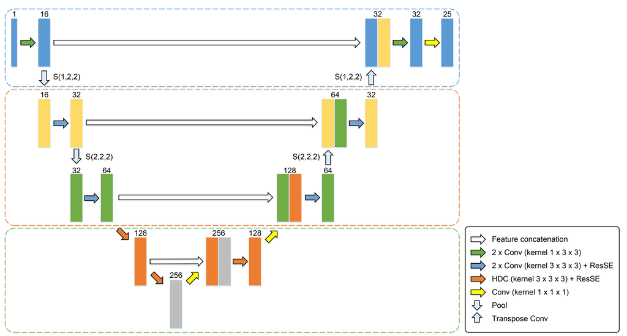

The replicated code representing the architercture above is shown below:

```python
class OrganNet(nn.Module):

    def __init__(self, channel: int = 10) -> None:
        super().__init__()

        # 2xConv 1,3,3 : green arrows
        self.conv3d2_1 = nn.Sequential(
            nn.Conv3d(1, 8, kernel_size=(1, 3, 3), padding='same'),
            nn.Conv3d(8, 16, kernel_size=(1, 3, 3), padding='same')
        )

        self.conv3d2_2 = nn.Sequential(
            nn.Conv3d(32, 32, kernel_size=(1, 3, 3), padding='same'),
            nn.Conv3d(32, 32, kernel_size=(1, 3, 3), padding='same')
        )

        # pool and transpose layers : white arrows
        self.pool1 = nn.MaxPool3d((1, 2, 2))
        self.pool2 = nn.MaxPool3d((2, 2, 2))
        self.transpose_2 = nn.ConvTranspose3d(64, 32, (2, 2, 2), stride=(2, 2, 2))
        self.transpose_1 = nn.ConvTranspose3d(32, 16, (1, 2, 2), stride=(1, 2, 2))

        # 2xConv 3,3,3 Resu and HDC
        self.convresu2_1 = ConvResu2(16, 32, False)
        self.convresu2_2 = ConvResu2(32, 64, False)
        self.hdc_1 = ConvResu2(64, 128, True)
        self.hdc_2 = ConvResu2(128, 256, True)
        self.convresu2_3 = ConvResu2(128, 64, False)
        self.convresu2_4 = ConvResu2(64, 32, False)

        # Conv 1 kernel
        self.conv1_1 = nn.Conv3d(256, 128, kernel_size=(1, 1, 1), padding='same')
        self.conv1_2 = nn.Conv3d(128, 64, kernel_size=(1, 1, 1), padding='same')
        self.conv1_3 = nn.Conv3d(32, channel, kernel_size=(1, 1, 1), padding='same')

        # HDC kernel
        self.hdc_2 = ConvResu2(128, 256, True)
        self.hdc_3 = ConvResu2(256, 128, True)

        # Softmax the output
        self.softmax = nn.Softmax(dim=1)

    def forward(self, x):

        blue_concat = self.conv3d2_1(x)

        x = self.pool1(blue_concat)

        yellow_concat = self.convresu2_1(x)

        x = self.pool2(yellow_concat)

        green_concat = self.convresu2_2(x)
        orange_concat = self.hdc_1(green_concat)

        x = self.hdc_2(orange_concat)
        x = self.conv1_1(x)

        x = torch.cat((x, orange_concat), 1)
        x = self.hdc_3(x)

        x = self.conv1_2(x)

        x = torch.cat((green_concat, x), 1)
        x = self.convresu2_3(x)

        x = self.transpose_2(x)

        x = torch.cat((yellow_concat, x), 1)
        x = self.convresu2_4(x)

        x = self.transpose_1(x)

        x = torch.cat((blue_concat, x), 1)
        x = self.conv3d2_2(x)
        x = self.conv1_3(x)

        return self.softmax(x)

    def save_checkpoint(self, optimizer, filename=os.path.join('models', 'model_checkpoint.pth')):
        checkpoint = {
            "state_dict": self.state_dict(),
            "optimizer": optimizer.state_dict(),
        }
        torch.save(checkpoint, filename)

    def load_checkpoint(self, checkpoint_file, optimizer, lr=0.0001):
        checkpoint = torch.load(checkpoint_file, map_location=DEVICE)
        self.load_state_dict(checkpoint["state_dict"])
        optimizer.load_state_dict(checkpoint["optimizer"])

        for param_group in optimizer.param_groups:
            param_group["lr"] = lr
```

To get a better understanding of the 2x Conv + ResSE block, a zoomed in architecture is depicted below. Additionally between the ReLu and second 3D Convolution block a batch normalization was applied. In this way the output of each level is normalized and then being used as input of the next level. This is done to get a faster convergence.

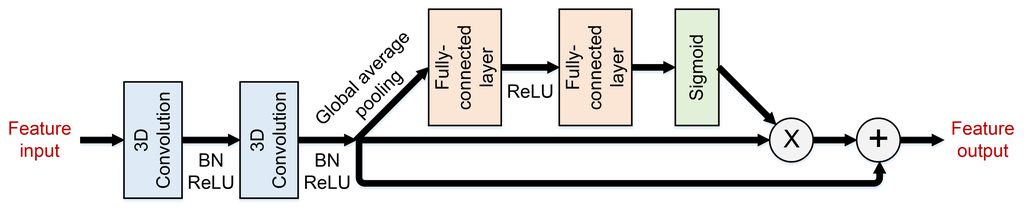

The replicated code representing the architercture above is shown below:

```python
class ConvResu2(nn.Module):
    def __init__(self, channel_in: int, channel_out: int, HDC: bool, reduction=4) -> None:
        super().__init__()

        self.channel_out = channel_out
        half_out = channel_in + (int((channel_out - channel_in) / 2))
        self.h = half_out
        if not HDC:
            self.conv_block = nn.Sequential(
                nn.Conv3d(channel_in, half_out, kernel_size=(3, 3, 3), padding='same'),
                nn.ReLU(),
                nn.BatchNorm3d(half_out),
                nn.Conv3d(half_out, channel_out, kernel_size=(3, 3, 3), padding='same'),
                nn.ReLU(),
            )

        else:
            self.conv_block = nn.Sequential(
                nn.Conv3d(channel_in, channel_out, kernel_size=(3, 3, 3), dilation=(3, 3, 3), padding='same'),
                nn.ReLU(),
            )

        self.global_pool = nn.AdaptiveAvgPool3d(1)

        self.pool_dense = nn.Sequential(
            nn.Linear(channel_out, channel_out // reduction),
            nn.ReLU(),
            nn.Linear(channel_out // reduction, channel_out),
            nn.Sigmoid()
        )

    def forward(self, x):

        x1 = self.conv_block(x)
        b, c, _, _, _ = x1.size()
        x2 = self.global_pool(x1).view(b, c)
        x2 = self.pool_dense(x2).view(b, c, 1, 1, 1)

        return torch.add(torch.mul(x1, x2), x1)


net = OrganNet(OUT_CHANNEL).to(DEVICE)
```

## 2 Reproduction

This section describes how we constituted our reproduced model, the version of the data we used and what training behaviour we observed. We created our model using the PyTorch library, and used the TorchIO library [3] for loading and preprocessing of the 3D medical images. We recreated the network design based mostly on the image model shown above, and for missing details or insights we consulted referenced literature of U-Net models [4], as the reproduced network is a variant of this.

### 2.1 Data

For the training and testing of the model, we use the MICCAI 2015 challenge dataset. Since the original dataset contains images from different sources (e.g. different CT scans used), resulting in an unequally spaced image set, we used a resampled version of the data from this [repository](https://github.com/prerakmody/hansegmentation-uncertainty-qa/releases), where the data was resampled so that all samples have an equal voxel spacing of (0.8, 0.8, 2.5) mm. There are in total 43 images in the training and offsite test sets. We use the first set of 25 images for training, the additional training set of 8 images for validation and the remaining 10 images from the offsite test set for testing. Upon loading the images width (W) and height (H) were cropped to (220, 220) pixels and then resized to (256, 256, 48) pixels. We ensured to randomly order the images upon loading them by setting `shuffle=True`. Extracting of patches, which was suggested to improve training time and deal with class imbalance between large and small organs, was not performed at this stage of reproduction.

```python
class MICCAI(Dataset):
    images = []
    labels = []
    patients = []
    channel_encode = 10

    transform = tio.Compose([
        tio.Crop((110, 110, 110, 110, 0, 0)),
        tio.Resize((256, 256, 48))
    ])

    def __init__(self, data_set: str, load: bool = False):
        super(MICCAI, self).__init__()
        self.data_set = data_set
        if load:
            with open('data/' + data_set + '.pickle', 'rb') as handle:
                self.images, self.labels, self.patients = pickle.load(handle)

        else:
            norm = tio.RescaleIntensity(out_min_max=(0, 1))

            data_path = os.path.join('data', data_set, 'data_3D')

            for subject_code in os.listdir(data_path):
                if os.path.isdir(os.path.join(data_path, subject_code)):
                    patient_path = os.path.join(data_path, subject_code)
                    files = os.listdir(patient_path)
                    patient_data = None
                    label = None
                    for file in files:
                        if 'img' in file and 'mha' in file and 'resampled' in file:
                            patient_data = file

                        if 'mask' in file and 'resampled' in file:
                            label = file

                    label = self.transform(tio.LabelMap(os.path.join(patient_path, label), type=tio.LABEL))
                    label = label.tensor.type(torch.LongTensor)

                    image = self.transform(tio.ScalarImage(os.path.join(patient_path, patient_data)))
                    image = norm(image.tensor.float())

                    assert image.max() <= 1

                    self.labels.append(label)
                    self.images.append(image)
                    self.patients.append(patient_path.split('/')[-1])

            with open('data/' + data_set + '.pickle', 'wb') as handle:
                pickle.dump((self.images, self.labels, self.patients), handle)

    def __len__(self):
        return len(self.labels)

    def _encode(self, tensor):
        result = torch.empty(10, 256, 256, 48)
        for i in range(self.channel_encode):
            result[i] = torch.where(tensor == i, 1, 0)

        return result

    def __getitem__(self, index):
        label = self._encode(self.labels[index])
        image = self.images[index]
        return image, label, self.patients[index]


# get the data from the dataloader, paper: batch size = 2
BATCH_SIZE = 2
load_train_set = True if 'train.pickle' in os.listdir('data') else False
training_data = MICCAI('train', load=load_train_set)

load_val_data = True if 'train_additional.pickle' in os.listdir('data') else False
validation_data = MICCAI('train_additional', load=load_val_data)

train_dataloader = DataLoader(training_data, batch_size=BATCH_SIZE, shuffle=True)
validation_dataloader = DataLoader(validation_data, batch_size=BATCH_SIZE, shuffle=True)
```

### 2.2 Training

A number of hyperparameters and configurations were set similar to the original paper, and will be given here for transparancy. For hybrid dilated convolutions (HDCs), a dilation rate of 3 was used. For the focal loss, we set $\gamma = 2$, and we used similar fixed weights per organ, thus $\alpha = [0.5, 1.0, 4.0, 1.0, 4.0, 4.0, 1.0, 1.0, 3.0, 3.0]$ (only for the 10 organs in this data set). For the combined loss, we simply set $\lambda = 1$, so dice loss contributes equally as focal loss. We similarly ran our training on a MSI GeForce GTX 1080Ti GPU (11GB VRAM) with a batch size of 2, for 68 epochs. The Adam optimizer has an initial learning rate of 0.001, which decays to 0.0001 after 50 epochs. In this configuration, training the model took around 2 hours.

### 2.3 Training results

After implementing a valid network design, performance of training was assessed by evaluating the combined loss over incrementing epochs. In the figure below we see the progression of the loss over relevant epochs (running loss = RED, validation loss = BLUE).

```python
# Train the model
for epoch in range(EPOCH):
    running_loss = 0.0
    validation_loss = 0.0

    for i, data in enumerate(train_dataloader):
        inputs, labels, patient = data[0].to(DEVICE), data[1].to(DEVICE), data[2]

        optimizer.zero_grad()
        outputs = net(inputs)

        loss_dice = criterion_dice(outputs, labels)
        loss_focal = criterion_focal(outputs, labels)

        loss = loss_dice + loss_focal
        loss.backward()
        optimizer.step()
        running_loss += loss.item()
```

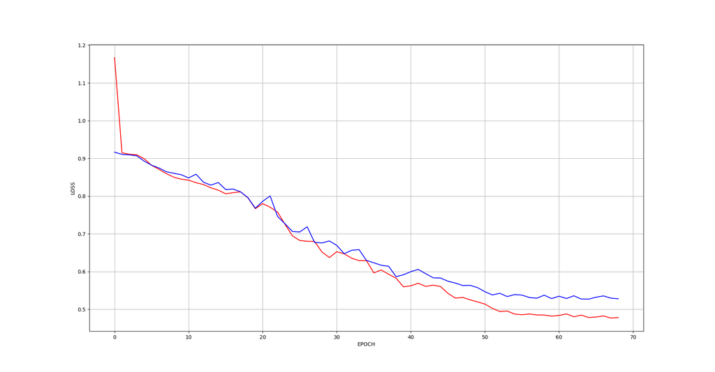

## 3 Results

In this chapter the results of the performance on the test set are discussed, for which we use the Dice Similarity Coefficent (DSC).

### 3.2 Dice Similarity Coefficient (DSC)

The DSC is a spatial overlap index and a reproducibility validation metric. The value ranges from 0 to 100, where 0 would indicate no overlap between output and label, and 100 would mean a complete overlap between the two. The equation is as follows:

$$ DSC = \frac{2\cdot |y ∩ ŷ|}{|y| + |ŷ|} \cdot 100 $$

Where y is the ground truth and ŷ is the prediction of the model. The vertical bars refer to the cardinality of the set, or the number of elements in that set belonging to a certain class or organ. '∩' refers to the intersection of the two sets, so the shared elements. This score is evaluated for every organ.

### 3.2 Test results

| Organ | Mean DSC | paper Mean DSC |
| --- | --- | --- |
| Background | 99.92 | not reported |
| Brain Stem | 60.6 | 87.2 |
| Opt. Chiasm | 0 | 66.3 |
| Mandible | 77.48 | 92.2 |
| Opt. Ner. L | 0 | 75.0 |
| Opt. Ner. R | 0 | 74.1 |
| Parotid L | 71.45 | 86.7 |
| Parotid R | 72.61 | 85.8 |
| Subman. L | 47.25 | 82.1 |
| Subman. R | 49.33 | 82.1 |

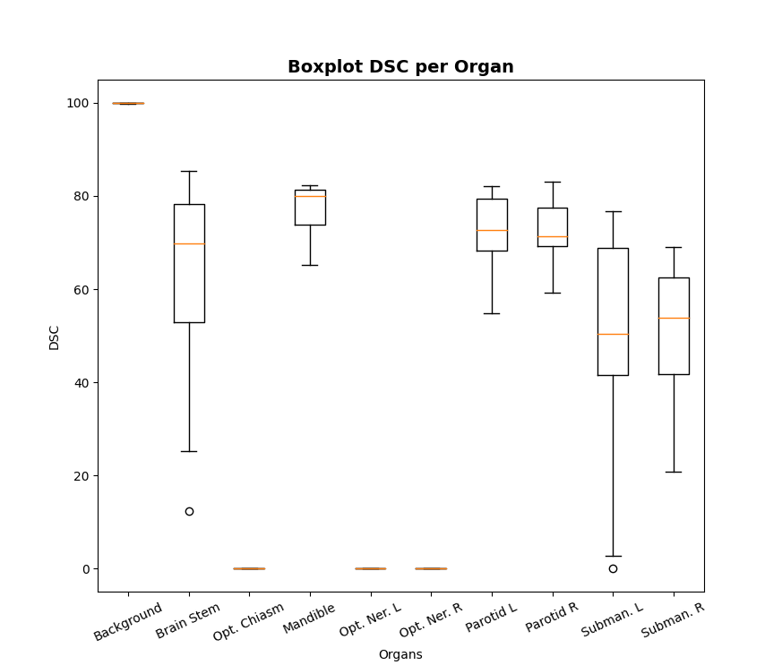

## Discussion

**1)** On multiple occasions the paper left out some important implementation details. This caused multiple issues during the reproduction. Also, for some parameters, it's unclear if this will result in a performance increase.

**2)** We implemented the focalloss directly from the formula of the paper. However, the loss drops very quickly. After half an epoch the loss is already less than 0.009 and jumps up and down after that. We are unsure if this is an implementation bug on our side. Or, if this is expected behavior.

**3)** The paper does not mention the use of an activation function at the end of the model. This is important as this greatly influences the loss calculation. It was not directly clear to us that we needed to implement a softmax activation function. This activation should probably be used as this can return a probability over all the channels, and could thus inform on the most likely organ.

**4)** Preprocessing of the data. The original paper does not mention anything about pre-processing data other than resizing it to the input size of the network. From analyzing the MICCA2015 dataset we found that the margins of black around the samples greatly differ. Some samples have over 200 pixels of black on both sides of both the H and W dimension. Whereas, others have only around 60 pixels. Considering the class imbalance in the data, more than 99,99% being the background, it is highly that the original paper did some other preprocessing.

### Conclusion

For some organs we seem to be getting relatively close to the original paper reported scores. For the smaller organs, however, we are not even getting close. We suspect this has mostly to do with missing implementation details. We expect to achieve similar results if all the implementation details would exactly match the original paper.

#### Contribution

Emma Botten - Loss functions, blog writing

Lucas Veeger - Dataloader, loss functions, blog writing

Storm Holman - Model, inferencing/results, blog writing

Thomas Zuiker - Dataloader, model, training

## References

1. R. Zhao et al., "Rethinking Dice Loss for Medical Image Segmentation," 2020 IEEE International Conference on Data Mining (ICDM), 2020, pp. 851-860, doi: 10.1109/ICDM50108.2020.00094.
2. Chen, Z. et al. (2021). A Novel Hybrid Convolutional Neural Network for Accurate Organ Segmentation in 3D Head and Neck CT Images. In: , et al. Medical Image Computing and Computer Assisted Intervention – MICCAI 2021. MICCAI 2021. Lecture Notes in Computer Science(), vol 12901. Springer, Cham. https://doi.org/10.1007/978-3-030-87193-2_54
3. F. Pérez-García, R. Sparks, and S. Ourselin. TorchIO: a Python library for efficient loading, preprocessing, augmentation and patch-based sampling of medical images in deep learning. Computer Methods and Programs in Biomedicine (June 2021), p. 106236. ISSN: 0169-2607.doi:10.1016/j.cmpb.2021.106236.
4. Ronneberger, O., Fischer, P., Brox, T.: U-Net: Convolutional networks for biomedical image segmentation. In: Navab, N., Hornegger, J., Wells, W., Frangi, A. (eds.) MICCAI 2015, LNCS, vol. 9351, pp. 234{241. Springer, Cham (2015). https://doi.org/10.1007/978-3-319-24574-4 28
5. Zhang, Y., Liu, S., Li, C., & Wang, J. (2021). Rethinking the Dice Loss for Deep Learning Lesion Segmentation in Medical Images. In Journal of Shanghai Jiaotong University (Science) (Vol. 26, Issue 1, pp. 93–102). Springer Science and Business Media LLC. https://doi.org/10.1007/s12204-021-2264-x
6. Han, X., Hoogeman, M.S., Levendag, P.C., Hibbard, L.S., Teguh, D.N., Voet, P., Cowen, A.C., Wolf, T.K.: Atlas-based auto-segmentation of head and neck CT images. In: Metaxas D., Alex L., Fichtinger G., Szekely G. (eds.) MICCAI 2008, LNCS, vol. 5242, pp. 434–441. Springer, Berlin, Heidelberg (2008). https://doi.org/10.1007/978-3-540-85990-1 52